# Grinina Yulia ML Project

### Удовлетворённость

```python
clean_df[['job_satisfaction', 'labour_conditions_satisfaction']]
```

|  | job_satisfaction | labour_conditions_satisfaction |
| --- | --- | --- |
| 0 | 2.00 | 2.00 |
| 1 | 2.00 | 2.00 |
| 2 | 1.00 | 1.00 |
| 3 | 3.00 | 4.00 |
| 4 | 3.00 | 3.00 |
| ... | ... | ... |
| 4273 | 3.00 | 3.00 |
| 4274 | 1.00 | 2.00 |
| 4275 | 2.00 | 2.00 |
| 4276 | 1.00 | 1.00 |
| 4277 | 1.00 | 3.00 |

4278 rows × 2 columns

```python
# создадим функцию для всех переменных удовлетворённости, вариант да/нет отнесён к неудовлетворён;
# 1 - удовлетворён, 0 - не удовлетворён
def satisfaction(df, col): # создадим функцию для бинарных переменных

    df[col] = df[col].apply(lambda x: 1 if x == 1 or x == 2 else 0)
    display(df[col].value_counts())
    display(df[col].isna().sum())
    df[col].hist()
```

```
job_satisfaction
1    3295
0     983
Name: count, dtype: int64
```

```
0
```

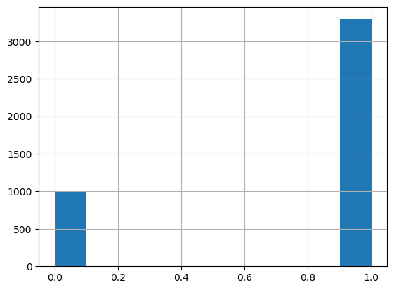

```python
# удовлетворённость работой
clean_df['job_satisfaction'].value_counts()
satisfaction(clean_df, 'job_satisfaction')
```

```
labour_conditions_satisfaction
1    3323
0     955
Name: count, dtype: int64
```

```
0
```

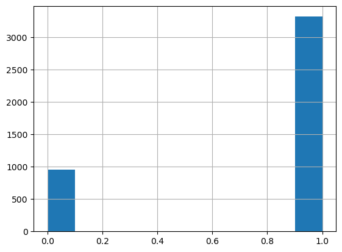

```python
# удовлетворённость условиями труда
satisfaction(clean_df, 'labour_conditions_satisfaction')
```

```
salary_satisfaction
0    2443
1    1835
Name: count, dtype: int64
```

```
0
```

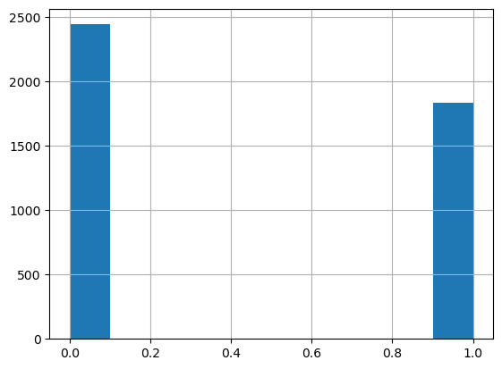

```python
satisfaction(clean_df, 'salary_satisfaction') # удовлетворённость заработной платой
```

```
promotion_satisfaction
1    2642
0    1636
Name: count, dtype: int64
```

```
0
```

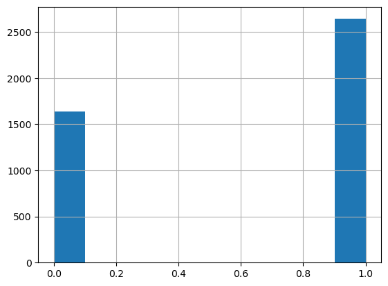

```python
# возможности профессионального роста
satisfaction(clean_df, 'promotion_satisfaction')
```

```
financial_situation_satisfaction
0    3153
1    1125
Name: count, dtype: int64
```

```
0
```

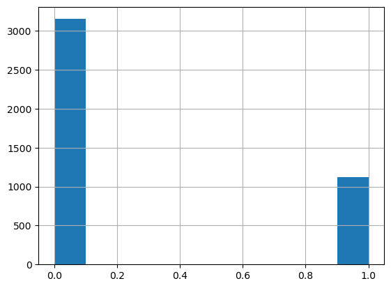

```python
#  удовлетворённость финансовым состоянием
satisfaction(clean_df, 'financial_situation_satisfaction')
```

```
life_satisfaction
1    2681
0    1597
Name: count, dtype: int64
```

```
0
```

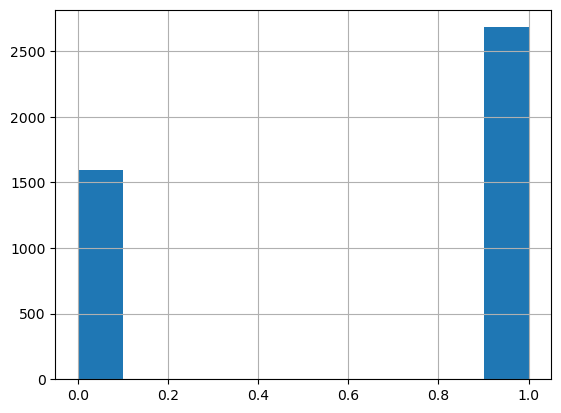

```python
# удовлетворение жизнью
satisfaction(clean_df,'life_satisfaction')
```

```
management_trust
1    3337
0     941
Name: count, dtype: int64
```

```
0
```

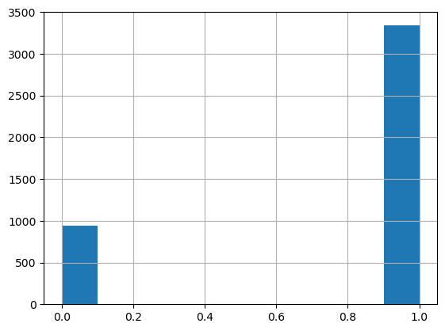

```python
# доверие руководству,1 - да
satisfaction(clean_df, 'management_trust')
```

```
colleagues_trust
1    3610
0     668
Name: count, dtype: int64
```

```
0
```

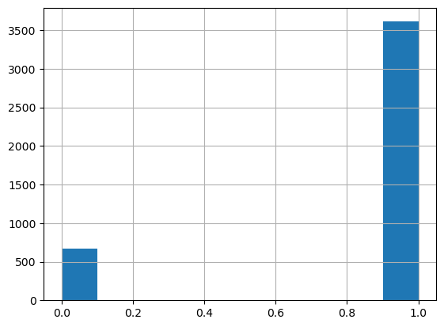

```python
# доверие коллегам
satisfaction(clean_df, 'colleagues_trust')
```

```
colleagues_trust
1    3610
0     668
Name: count, dtype: int64
```

```
0
```

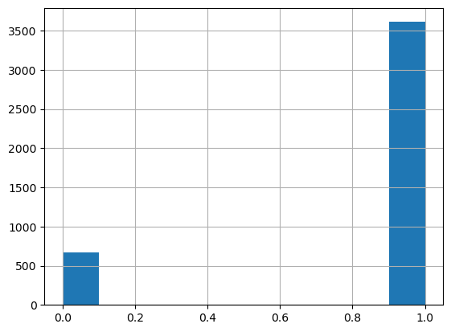

```python
# уверенность в нахождении новой работы
satisfaction(clean_df, 'colleagues_trust')
```

```
health
0    2145
1    2133
Name: count, dtype: int64
```

```
0
```

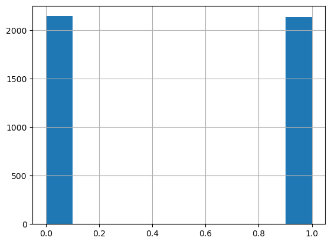

```python
# уровень здоровья, 1 - хооршее
satisfaction(clean_df,'health')
```

```
new_job_confidence
0    2424
1    1854
Name: count, dtype: int64
```

```
0
```

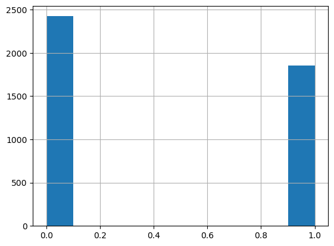

```python
satisfaction(clean_df, 'new_job_confidence') # уверенность в нахождении новой работы
```

# Построение модели

```python
df = clean_df[['male', 'age', 'age2', 'capital', 'city', 'urban_type', 'marital_status', 'secondary_edu', 'proff_edu', 'high_edu', 'high_qualifited', \
            'maternity_leave', 'vacation', 'kids', 'job_satisfaction', 'labour_conditions_satisfaction', 'salary_satisfaction', \
             'promotion_satisfaction', 'work_schedule', 'hazardous_industry', 'state_owner', 'foreign_owner', 'self_owner', 'management_trust', \
             'colleagues_trust', 'new_job_confidence', 'life_satisfaction', 'financial_situation_satisfaction', 'courses', 'foreign_language', \
            'health', 'disability', 'depression', 'experience', 'experience^2', 'log_salary']]
```

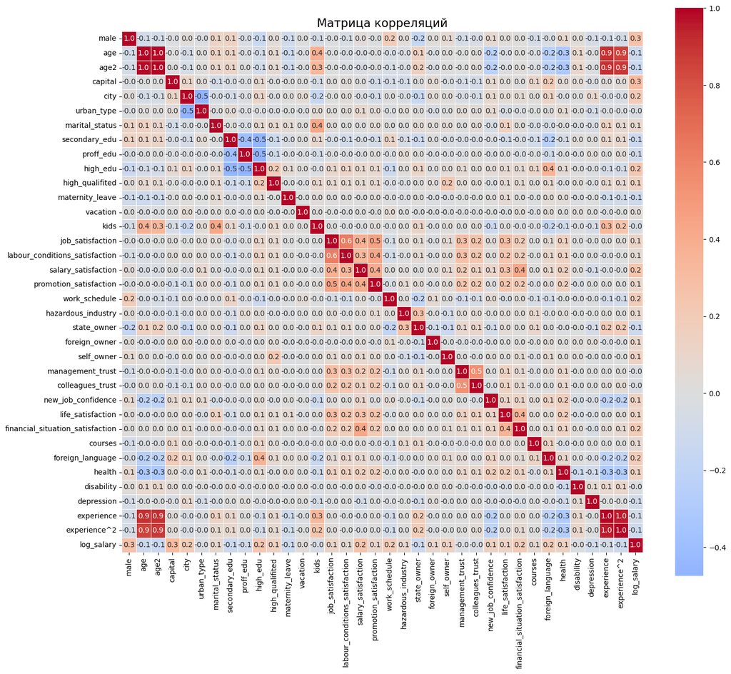

```python
corr = df.corr()

plt.figure(figsize=(15, 15))
sns.heatmap(corr,
            annot=True,
            fmt='.1f',
            cmap='coolwarm',
            center=0,
            square=True,
            linewidths=0.5,
            cbar_kws={"shrink": 0.8})

plt.title('Матрица корреляций', fontsize=16)
plt.tight_layout()
plt.show()
```

```python
#выявляем признаки с высокой корреляцией
corr_matrix = np.array(df.corr().abs())
for i, j in zip(np.where(corr_matrix > 0.7)[0], np.where(corr_matrix > 0.7)[1]):
    if i != j: #не учитываем диагональ
        print(f'Признак {df.columns[i]} сильно коррелирует с признаком {df.columns[j]}')
```

```
Признак age сильно коррелирует с признаком age2
Признак age сильно коррелирует с признаком experience
Признак age сильно коррелирует с признаком experience^2
Признак age2 сильно коррелирует с признаком age
Признак age2 сильно коррелирует с признаком experience
Признак age2 сильно коррелирует с признаком experience^2
Признак experience сильно коррелирует с признаком age
Признак experience сильно коррелирует с признаком age2
Признак experience сильно коррелирует с признаком experience^2
Признак experience^2 сильно коррелирует с признаком age
Признак experience^2 сильно коррелирует с признаком age2
Признак experience^2 сильно коррелирует с признаком experience
```

Таким образом мультиколлениарность наблюдается у признаков age и experience - учитываем их по отдельности в разных спецификациях

```python
X = df.drop('log_salary', axis=1)
y = df['log_salary']

rf = RandomForestRegressor(n_estimators=100, random_state=42, n_jobs=-1)
rf.fit(X, y)
```

```
RandomForestRegressor(n_jobs=-1, random_state=42)
```

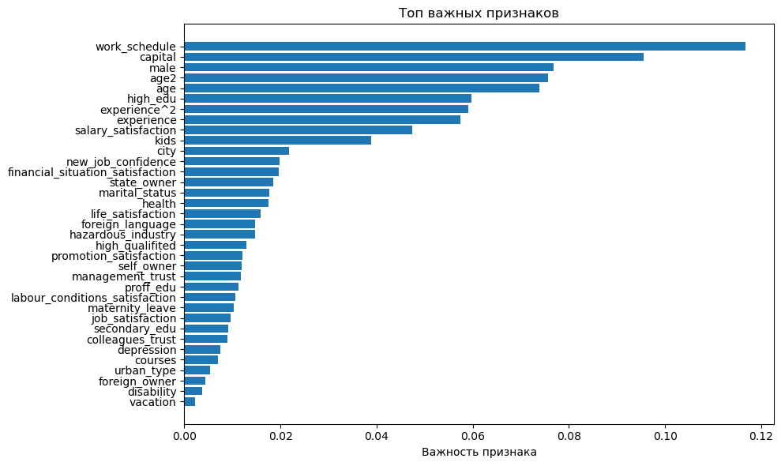

```
Отобрано 26 признаков:
1. work_schedule
2. capital
3. male
4. age2
5. age
6. high_edu
7. experience^2
8. experience
9. salary_satisfaction
10. kids
11. city
12. new_job_confidence
13. financial_situation_satisfaction
14. state_owner
15. marital_status
16. health
17. life_satisfaction
18. foreign_language
19. hazardous_industry
20. high_qualifited
21. promotion_satisfaction
22. self_owner
23. management_trust
24. proff_edu
25. labour_conditions_satisfaction
26. maternity_leave
```

```python
feature_importance = pd.DataFrame({
    'feature': X.columns,
    'importance': rf.feature_importances_
}).sort_values('importance', ascending=False)

plt.figure(figsize=(10, 6))
plt.barh(feature_importance['feature'],
         feature_importance['importance'])
plt.xlabel('Важность признака')
plt.title('Топ важных признаков')
plt.gca().invert_yaxis()
plt.tight_layout()
plt.show()

# Выбор порога (важность > 0.01)
threshold = 0.01  # минимальная важность
selected_features = feature_importance[feature_importance['importance'] > threshold]['feature'].tolist()
# selected_features = feature_importance.head(10)['feature'].tolist()
print(f"Отобрано {len(selected_features)} признаков:")
for i, feat in enumerate(selected_features, 1):
    print(f"{i}. {feat}")
```

```python
df=df.drop(['job_satisfaction', 'colleagues_trust', 'depression', 'courses', 'foreign_owner', 'disability', 'vacation'], axis=1)
```

## I Спецификация

Основу эконометрического анализа в данном исследовании составляет уравнение Минсера (Mincer, 1974), разработанное Джейкобом Минсером в 1974 году, которое стало классическим инструментом для оценки влияния человеческого капитала на заработную плату.

**Формально уравнение записывается как:**

$$ \ln(\omega_i) = \beta_0 + \beta_1 S_i + \beta_2 E_i + \beta_3 E_i^2 + \gamma X_i + \varepsilon_i $$

**где:**

- $\ln(\omega_i)$ — натуральный логарифм заработной платы $i$-го индивида
- $S_i$ — количество лет образования
- $E_i$ — опыт работы (рассчитывается как $\text{возраст} - \text{годы образования} - 6$)
- $E_i^2$ — квадрат опыта работы (учитывает убывающую предельную отдачу от опыта)
- $X_i$ — вектор контрольных переменных (пол, регион, отрасль и др.)
- $\varepsilon_i$ — случайная ошибка

```python
rdf = df.copy()
```

```python
r_ols1 = sm.OLS(
    endog=rdf['log_salary'],
    exog=sm.add_constant(
        rdf[['male', 'age', 'age2', 'high_qualifited', 'work_schedule']])
).fit()
# r_ols1.summary()
```

**Гетероскедастичность**

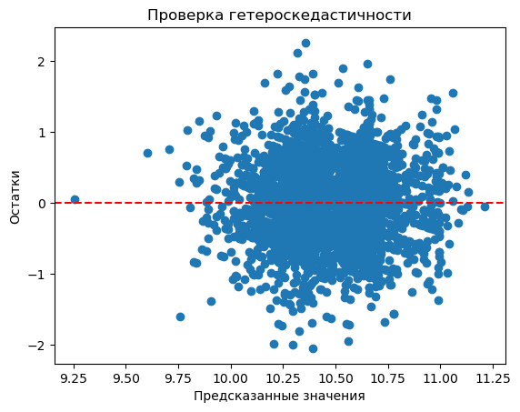

```python
fitted = r_ols1.fittedvalues
residuals = r_ols1.resid

plt.scatter(fitted, residuals)
plt.axhline(y=0, color='r', linestyle='--')
plt.xlabel("Предсказанные значения")
plt.ylabel("Остатки")
plt.title("Проверка гетероскедастичности")
plt.show()
```

```python
# выполняем тест Бреуша-Пэгана
bptest = smd.het_breuschpagan(resid=r_ols1.resid, exog_het=sm.add_constant(rdf[['male', 'age', 'age2', 'high_qualifited', 'work_schedule']]))
print("\nТест Бреуша-Пагана на гетероскедастичность")
print(f"LM-статистика: {bptest[0]:.4f}")
print(f"p-value: {bptest[1]:.4f}")
print(f"F-статистика: {bptest[2]:.4f}")
print(f"F p-value: {bptest[3]:.4f}")

if bptest[1] < 0.05:
    print("\nВывод: Присутствует гетероскедастичность (p-value < 0.05).")
else:
    print("\nВывод: Гетероскедастичность не обнаружена (p-value >= 0.05).")
    print("Можно использовать стандартные ошибки OLS.")
```

```
Тест Бреуша-Пагана на гетероскедастичность
LM-статистика: 44.0976
p-value: 0.0000
F-статистика: 8.8989
F p-value: 0.0000

Вывод: Присутствует гетероскедастичность (p-value < 0.05).
```

Так как присутствует гетероскедастичность, то применим робастные стандартные ошибки (Huber-White) Исправляют оценки стандартных ошибок без изменения коэффициентов

```python
r_ols1 = sm.OLS(
    endog=rdf['log_salary'],
    exog=sm.add_constant(
        rdf[['male', 'age', 'age2', 'high_qualifited', 'work_schedule']])
).fit(cov_type='HC3')
r_ols1.summary()
```

OLS Regression Results

| Dep. Variable: | log_salary | R-squared: | 0.141 |
| --- | --- | --- | --- |
| Model: | OLS | Adj. R-squared: | 0.140 |
| Method: | Least Squares | F-statistic: | 125.7 |
| Date: | Mon, 08 Dec 2025 | Prob (F-statistic): | 1.74e-124 |
| Time: | 20:36:46 | Log-Likelihood: | -3227.2 |
| No. Observations: | 4278 | AIC: | 6466. |
| Df Residuals: | 4272 | BIC: | 6505. |
| Df Model: | 5 |  |  |
| Covariance Type: | HC3 |  |  |

|  | coef | std err | z | P>\|z\| | [0.025 | 0.975] |
| --- | --- | --- | --- | --- | --- | --- |
| const | 9.4007 | 0.098 | 96.124 | 0.000 | 9.209 | 9.592 |
| male | 0.2619 | 0.016 | 16.287 | 0.000 | 0.230 | 0.293 |
| age | 0.0368 | 0.004 | 8.676 | 0.000 | 0.028 | 0.045 |
| age2 | -0.0005 | 4.82e-05 | -9.700 | 0.000 | -0.001 | -0.000 |
| high_qualifited | 0.3330 | 0.041 | 8.161 | 0.000 | 0.253 | 0.413 |
| work_schedule | 0.0069 | 0.001 | 7.468 | 0.000 | 0.005 | 0.009 |

| Omnibus: | 40.838 | Durbin-Watson: | 1.382 |
| --- | --- | --- | --- |
| Prob(Omnibus): | 0.000 | Jarque-Bera (JB): | 65.209 |
| Skew: | 0.042 | Prob(JB): | 6.92e-15 |
| Kurtosis: | 3.599 | Cond. No. | 2.81e+04 |

Notes:  
[1] Standard Errors are heteroscedasticity robust (HC3)  
[2] The condition number is large, 2.81e+04. This might indicate that there are  
strong multicollinearity or other numerical problems.

```python
residuals.mean()
```

```
2.327663593012636e-12
```

**Тест Рамсея** (RESET-тест) выявляет ошибки спецификации модели линейной регрессии.

Некоторые из таких ошибок:

- Наличие пропущенных переменных. Регрессия содержит не все объясняющие переменные.
- Неверная функциональная форма. Некоторые или все переменные нужно преобразовать с помощью логарифмической, степенной, обратной или другой функции.
- Корреляция между фактором Х и случайной составляющей модели. Она может быть вызвана ошибками измерения факторов, рассмотрением систем уравнений или другими причинами.

```python
resettest = smd.linear_reset(res=r_ols1, power=2, test_type="fitted", use_f=True)
print(resettest)
if resettest.pvalue < 0.05:
        print("Отклоняем нулевую гипотезу. Модель страдает от пропущенной нелинейности")
else:
        print("Не отклоняем нулевую гипотезу. Модель линейно адекватна")
```

```
<F test: F=1.4320477921950348, p=0.23149694979531826, df_denom=4.27e+03, df_num=1>
Не отклоняем нулевую гипотезу. Модель линейно адекватна
```

**Мультиколлениарность** Интерпретация: VIF > 10 — критическая мультиколлинеарность.

```python
X = rdf[['male', 'age', 'age2', 'high_qualifited', 'work_schedule']]
vif = [variance_inflation_factor(X.values, i) for i in range(X.shape[1])]
print(f"VIF: {dict(zip(X.columns, vif))}")
```

```
VIF: {'male': 1.9235545747354654, 'age': 92.88205570834948, 'age2': 44.035730056411104, 'high_qualifited': 1.0662688637325446, 'work_schedule': 17.227988780017952}
```

## II Спецификация

Построим типичное уравнение Минсера через стаж

```python
r_ols2 = sm.OLS(
    endog=rdf['log_salary'],
    exog=sm.add_constant(
        rdf[['male', 'experience', 'experience^2', 'high_qualifited', 'work_schedule']])
).fit()
```

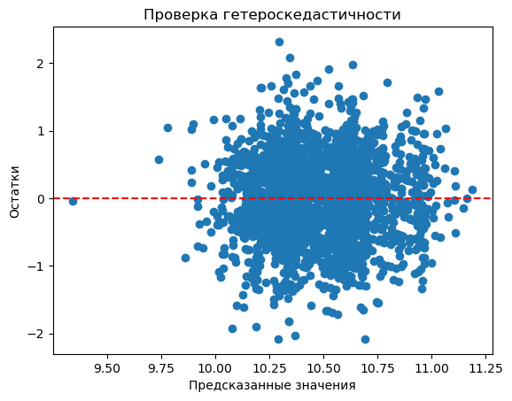

```python
fitted = r_ols2.fittedvalues
residuals = r_ols2.resid

plt.scatter(fitted, residuals)
plt.axhline(y=0, color='r', linestyle='--')
plt.xlabel("Предсказанные значения")
plt.ylabel("Остатки")
plt.title("Проверка гетероскедастичности")
plt.show()
```

```python
bptest = smd.het_breuschpagan(resid=r_ols2.resid, exog_het=sm.add_constant(rdf[['male', 'experience', 'experience^2', 'high_qualifited', 'work_schedule']]))
print("\nТест Бреуша-Пагана на гетероскедастичность")
print(f"LM-статистика: {bptest[0]:.4f}")
print(f"p-value: {bptest[1]:.4f}")
print(f"F-статистика: {bptest[2]:.4f}")
print(f"F p-value: {bptest[3]:.4f}")


if bptest[1] < 0.05:
    print("\nВывод: Присутствует гетероскедастичность (p-value < 0.05).")
else:
    print("\nВывод: Гетероскедастичность не обнаружена (p-value >= 0.05).")
    print("Можно использовать стандартные ошибки OLS.")
```

```
Тест Бреуша-Пагана на гетероскедастичность
LM-статистика: 34.2356
p-value: 0.0000
F-статистика: 6.8927
F p-value: 0.0000

Вывод: Присутствует гетероскедастичность (p-value < 0.05).
```

Так как присутствует гетероскедастичность, то применим робастные стандартные ошибки (Huber-White) Исправляют оценки стандартных ошибок без изменения коэффициентов

```python
r_ols2 = sm.OLS(
    endog=rdf['log_salary'],
    exog=sm.add_constant(
        rdf[['male', 'experience', 'experience^2', 'high_qualifited', 'work_schedule']])
).fit(cov_type='HC3')
r_ols2.summary()
```

OLS Regression Results

| Dep. Variable: | log_salary | R-squared: | 0.125 |
| --- | --- | --- | --- |
| Model: | OLS | Adj. R-squared: | 0.124 |
| Method: | Least Squares | F-statistic: | 110.2 |
| Date: | Mon, 08 Dec 2025 | Prob (F-statistic): | 7.98e-110 |
| Time: | 20:36:47 | Log-Likelihood: | -3266.9 |
| No. Observations: | 4278 | AIC: | 6546. |
| Df Residuals: | 4272 | BIC: | 6584. |
| Df Model: | 5 |  |  |
| Covariance Type: | HC3 |  |  |

|  | coef | std err | z | P>\|z\| | [0.025 | 0.975] |
| --- | --- | --- | --- | --- | --- | --- |
| const | 9.9657 | 0.047 | 212.825 | 0.000 | 9.874 | 10.057 |
| male | 0.2645 | 0.016 | 16.269 | 0.000 | 0.233 | 0.296 |
| experience | 0.0137 | 0.002 | 6.240 | 0.000 | 0.009 | 0.018 |
| experience^2 | -0.0004 | 4.77e-05 | -7.696 | 0.000 | -0.000 | -0.000 |
| high_qualifited | 0.3315 | 0.041 | 8.097 | 0.000 | 0.251 | 0.412 |
| work_schedule | 0.0070 | 0.001 | 7.421 | 0.000 | 0.005 | 0.009 |

| Omnibus: | 42.232 | Durbin-Watson: | 1.398 |
| --- | --- | --- | --- |
| Prob(Omnibus): | 0.000 | Jarque-Bera (JB): | 69.360 |
| Skew: | 0.014 | Prob(JB): | 8.68e-16 |
| Kurtosis: | 3.623 | Cond. No. | 4.10e+03 |

Notes:  
[1] Standard Errors are heteroscedasticity robust (HC3)  
[2] The condition number is large, 4.1e+03. This might indicate that there are  
strong multicollinearity or other numerical problems.

```python
resettest = smd.linear_reset(res=r_ols2, power=2, test_type="fitted", use_f=True)
print(resettest)
if resettest.pvalue < 0.05:
        print("Отклоняем нулевую гипотезу. Модель страдает от пропущенной нелинейности")
else:
        print("Не отклоняем нулевую гипотезу. Модель линейно адекватна")
```

```
<F test: F=0.01167332905689034, p=0.9139665138829046, df_denom=4.27e+03, df_num=1>
Не отклоняем нулевую гипотезу. Модель линейно адекватна
```

```python
X = rdf[['male', 'experience', 'experience^2', 'high_qualifited', 'work_schedule']]
vif = [variance_inflation_factor(X.values, i) for i in range(X.shape[1])]
print(f"VIF: {dict(zip(X.columns, vif))}")
```

```
VIF: {'male': 1.9197907366070366, 'experience': 34.6933283637381, 'experience^2': 19.799456349219945, 'high_qualifited': 1.066106000471475, 'work_schedule': 6.910281693665694}
```

```python
rdf=rdf.drop(['experience', 'experience^2'], axis=1)
```

## Расширенная спецификация

Включение расширенного набора переменных в Минсеровское уравнение обусловлено необходимостью учета многомерных факторов, влияющих на заработную плату, и минимизации смещения оценок гендерного разрыва. Классические переменные - образование, опыт и пол - дополняются социально-демографическими, институциональными и психологическими характеристиками, что позволяет изолировать «чистый» эффект гендера от перекрывающихся факторов.

```python
r_ols4 = sm.OLS(
    endog=rdf['log_salary'],
    exog=sm.add_constant(
        rdf.drop('log_salary', axis=1))
).fit()
```

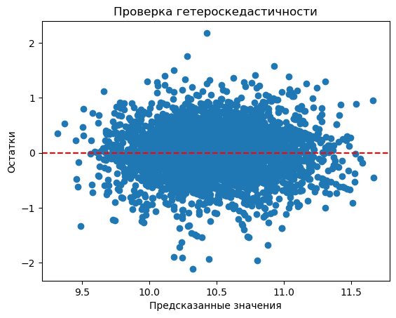

```python
fitted = r_ols4.fittedvalues
residuals = r_ols4.resid

plt.scatter(fitted, residuals)
plt.axhline(y=0, color='r', linestyle='--')
plt.xlabel("Предсказанные значения")
plt.ylabel("Остатки")
plt.title("Проверка гетероскедастичности")
plt.show()
```

```python
r_ols4 = sm.OLS(
    endog=rdf['log_salary'],
    exog=sm.add_constant(
        rdf.drop('log_salary', axis=1))
).fit(cov_type='HC3')
r_ols4.summary()
```

OLS Regression Results

| Dep. Variable: | log_salary | R-squared: | 0.407 |
| --- | --- | --- | --- |
| Model: | OLS | Adj. R-squared: | 0.403 |
| Method: | Least Squares | F-statistic: | 108.6 |
| Date: | Mon, 08 Dec 2025 | Prob (F-statistic): | 0.00 |
| Time: | 20:36:47 | Log-Likelihood: | -2435.1 |
| No. Observations: | 4278 | AIC: | 4924. |
| Df Residuals: | 4251 | BIC: | 5096. |
| Df Model: | 26 |  |  |
| Covariance Type: | HC3 |  |  |

|  | coef | std err | z | P>\|z\| | [0.025 | 0.975] |
| --- | --- | --- | --- | --- | --- | --- |
| const | 8.7096 | 0.101 | 86.111 | 0.000 | 8.511 | 8.908 |
| male | 0.2589 | 0.014 | 18.416 | 0.000 | 0.231 | 0.286 |
| age | 0.0420 | 0.004 | 10.670 | 0.000 | 0.034 | 0.050 |
| age2 | -0.0005 | 4.35e-05 | -11.538 | 0.000 | -0.001 | -0.000 |
| capital | 0.4351 | 0.017 | 25.266 | 0.000 | 0.401 | 0.469 |
| city | 0.1740 | 0.017 | 10.030 | 0.000 | 0.140 | 0.208 |
| urban_type | 0.0516 | 0.027 | 1.910 | 0.056 | -0.001 | 0.105 |
| marital_status | 0.0247 | 0.015 | 1.608 | 0.108 | -0.005 | 0.055 |
| secondary_edu | 0.0346 | 0.028 | 1.233 | 0.218 | -0.020 | 0.090 |
| proff_edu | 0.1072 | 0.028 | 3.763 | 0.000 | 0.051 | 0.163 |
| high_edu | 0.2953 | 0.029 | 10.013 | 0.000 | 0.238 | 0.353 |
| high_qualifited | 0.1702 | 0.035 | 4.883 | 0.000 | 0.102 | 0.239 |
| maternity_leave | -0.5274 | 0.092 | -5.706 | 0.000 | -0.709 | -0.346 |
| kids | 0.0053 | 0.008 | 0.669 | 0.503 | -0.010 | 0.021 |
| labour_conditions_satisfaction | -0.0594 | 0.018 | -3.353 | 0.001 | -0.094 | -0.025 |
| salary_satisfaction | 0.1889 | 0.016 | 11.848 | 0.000 | 0.158 | 0.220 |
| promotion_satisfaction | 0.0291 | 0.016 | 1.839 | 0.066 | -0.002 | 0.060 |
| work_schedule | 0.0084 | 0.001 | 10.066 | 0.000 | 0.007 | 0.010 |
| hazardous_industry | 0.1496 | 0.020 | 7.527 | 0.000 | 0.111 | 0.189 |
| state_owner | -0.0589 | 0.015 | -3.937 | 0.000 | -0.088 | -0.030 |
| self_owner | 0.2552 | 0.050 | 5.085 | 0.000 | 0.157 | 0.354 |
| management_trust | -0.0381 | 0.016 | -2.317 | 0.020 | -0.070 | -0.006 |
| new_job_confidence | 0.0162 | 0.014 | 1.150 | 0.250 | -0.011 | 0.044 |
| life_satisfaction | 0.0312 | 0.015 | 2.060 | 0.039 | 0.002 | 0.061 |
| financial_situation_satisfaction | 0.1038 | 0.018 | 5.722 | 0.000 | 0.068 | 0.139 |
| foreign_language | 0.0374 | 0.019 | 1.932 | 0.053 | -0.001 | 0.075 |
| health | 0.0351 | 0.014 | 2.466 | 0.014 | 0.007 | 0.063 |

| Omnibus: | 112.241 | Durbin-Watson: | 1.556 |
| --- | --- | --- | --- |
| Prob(Omnibus): | 0.000 | Jarque-Bera (JB): | 235.527 |
| Skew: | -0.144 | Prob(JB): | 7.18e-52 |
| Kurtosis: | 4.113 | Cond. No. | 3.34e+04 |

Notes:  
[1] Standard Errors are heteroscedasticity robust (HC3)  
[2] The condition number is large, 3.34e+04. This might indicate that there are  
strong multicollinearity or other numerical problems.

```python
resettest = smd.linear_reset(res=r_ols4, power=2, test_type="fitted", use_f=True)
print(resettest)
if resettest.pvalue < 0.05:
        print("Отклоняем нулевую гипотезу. Модель страдает от пропущенной нелинейности")
else:
        print("Не отклоняем нулевую гипотезу. Модель линейно адекватна")
```

```
<F test: F=1.0480859018155826, p=0.30600660006171604, df_denom=4.25e+03, df_num=1>
Не отклоняем нулевую гипотезу. Модель линейно адекватна
```

```python
X = rdf.drop('log_salary', axis=1)
vif = [variance_inflation_factor(X.values, i) for i in range(X.shape[1])]
print(f"VIF: {dict(zip(X.columns, vif))}")
```

[output not shown]

Интерпретация: VIF > 10 — критическая мультиколлинеарность.

## Перекрёстные переменные

Взаимодействие пола с другими переменными, позволяющее оценить, как эффект этих переменных на зарплату различается между мужчинами и женщинами. Например, влияние наличия детей на зарплату может быть разным для мужчин и женщин.

```python
rdf.columns.values
```

```
array(['male', 'age', 'age2', 'capital', 'city', 'urban_type',
       'marital_status', 'secondary_edu', 'proff_edu', 'high_edu',
       'high_qualifited', 'maternity_leave', 'kids',
       'labour_conditions_satisfaction', 'salary_satisfaction',
       'promotion_satisfaction', 'work_schedule', 'hazardous_industry',
       'state_owner', 'self_owner', 'management_trust',
       'new_job_confidence', 'life_satisfaction',
       'financial_situation_satisfaction', 'foreign_language', 'health',
       'log_salary'], dtype=object)
```

```python
cross_rdf = rdf.copy()
cross_rdf['male*marital_status'] = rdf['male'] * rdf['marital_status']
#Семейные мужчины часто получают «премию за брак», тогда женщины — «штраф» (особенно в частном секторе)
cross_rdf['male*high_edu'] = rdf['male'] * rdf['high_edu'] # Проверит, даёт ли высшее образование большую отдачу мужчинам
cross_rdf['male*kids'] = rdf['male'] * rdf['kids']  # Позволит выявить «штраф за материнство»: как наличие детей снижает зарплату женщин, но не мужчин
cross_rdf['male*high_qualifited'] = rdf['male'] * rdf['high_qualifited'] # Мужчинам на руководящих позициях платят больше
cross_rdf['male*work_schedule'] = rdf['male'] * rdf['work_schedule']
# Гибкие/ненормированные графики чаще доступны мужчинам и могут усиливать разрыв (например, доступ к сверхурочным).
```

```python
cross_r_ols = sm.OLS(
    endog=cross_rdf['log_salary'],
    exog=sm.add_constant(
        cross_rdf.drop('log_salary', axis=1))
).fit(cov_type='HC3')
cross_r_ols.summary()
```

OLS Regression Results

| Dep. Variable: | log_salary | R-squared: | 0.414 |
| --- | --- | --- | --- |
| Model: | OLS | Adj. R-squared: | 0.410 |
| Method: | Least Squares | F-statistic: | 94.07 |
| Date: | Mon, 08 Dec 2025 | Prob (F-statistic): | 0.00 |
| Time: | 20:36:48 | Log-Likelihood: | -2409.7 |
| No. Observations: | 4278 | AIC: | 4883. |
| Df Residuals: | 4246 | BIC: | 5087. |
| Df Model: | 31 |  |  |
| Covariance Type: | HC3 |  |  |

|  | coef | std err | z | P>\|z\| | [0.025 | 0.975] |
| --- | --- | --- | --- | --- | --- | --- |
| const | 8.7893 | 0.106 | 82.585 | 0.000 | 8.581 | 8.998 |
| male | 0.1349 | 0.076 | 1.778 | 0.075 | -0.014 | 0.284 |
| age | 0.0417 | 0.004 | 10.551 | 0.000 | 0.034 | 0.049 |
| age2 | -0.0005 | 4.39e-05 | -11.517 | 0.000 | -0.001 | -0.000 |
| capital | 0.4361 | 0.017 | 25.441 | 0.000 | 0.402 | 0.470 |
| city | 0.1721 | 0.017 | 9.982 | 0.000 | 0.138 | 0.206 |
| urban_type | 0.0533 | 0.027 | 1.981 | 0.048 | 0.001 | 0.106 |
| marital_status | -0.0368 | 0.020 | -1.884 | 0.060 | -0.075 | 0.001 |
| secondary_edu | 0.0321 | 0.028 | 1.152 | 0.249 | -0.023 | 0.087 |
| proff_edu | 0.1118 | 0.028 | 3.950 | 0.000 | 0.056 | 0.167 |
| high_edu | 0.3252 | 0.032 | 10.239 | 0.000 | 0.263 | 0.387 |
| high_qualifited | 0.1784 | 0.048 | 3.707 | 0.000 | 0.084 | 0.273 |
| maternity_leave | -0.5145 | 0.092 | -5.592 | 0.000 | -0.695 | -0.334 |
| kids | -0.0112 | 0.010 | -1.089 | 0.276 | -0.031 | 0.009 |
| labour_conditions_satisfaction | -0.0559 | 0.018 | -3.166 | 0.002 | -0.091 | -0.021 |
| salary_satisfaction | 0.1859 | 0.016 | 11.723 | 0.000 | 0.155 | 0.217 |
| promotion_satisfaction | 0.0274 | 0.016 | 1.740 | 0.082 | -0.003 | 0.058 |
| work_schedule | 0.0079 | 0.001 | 6.737 | 0.000 | 0.006 | 0.010 |
| hazardous_industry | 0.1464 | 0.020 | 7.395 | 0.000 | 0.108 | 0.185 |
| state_owner | -0.0549 | 0.015 | -3.661 | 0.000 | -0.084 | -0.025 |
| self_owner | 0.2582 | 0.051 | 5.107 | 0.000 | 0.159 | 0.357 |
| management_trust | -0.0368 | 0.016 | -2.246 | 0.025 | -0.069 | -0.005 |
| new_job_confidence | 0.0149 | 0.014 | 1.061 | 0.289 | -0.013 | 0.042 |
| life_satisfaction | 0.0279 | 0.015 | 1.848 | 0.065 | -0.002 | 0.058 |
| financial_situation_satisfaction | 0.1067 | 0.018 | 5.880 | 0.000 | 0.071 | 0.142 |
| foreign_language | 0.0392 | 0.019 | 2.039 | 0.041 | 0.002 | 0.077 |
| health | 0.0351 | 0.014 | 2.484 | 0.013 | 0.007 | 0.063 |
| male*marital_status | 0.1431 | 0.030 | 4.701 | 0.000 | 0.083 | 0.203 |
| male*high_edu | -0.0814 | 0.029 | -2.779 | 0.005 | -0.139 | -0.024 |
| male*kids | 0.0305 | 0.014 | 2.113 | 0.035 | 0.002 | 0.059 |
| male*high_qualifited | -0.0169 | 0.069 | -0.244 | 0.807 | -0.152 | 0.118 |
| male*work_schedule | 0.0008 | 0.002 | 0.466 | 0.641 | -0.002 | 0.004 |

| Omnibus: | 116.006 | Durbin-Watson: | 1.560 |
| --- | --- | --- | --- |
| Prob(Omnibus): | 0.000 | Jarque-Bera (JB): | 243.480 |
| Skew: | -0.154 | Prob(JB): | 1.35e-53 |
| Kurtosis: | 4.128 | Cond. No. | 3.64e+04 |

Notes:  
[1] Standard Errors are heteroscedasticity robust (HC3)  
[2] The condition number is large, 3.64e+04. This might indicate that there are  
strong multicollinearity or other numerical problems.

## Тест Чоу

```python
df_male = rdf[clean_df['male'] == 1]
df_female = rdf[clean_df['male'] == 0]
```

```python
X_pooled = sm.add_constant(rdf.drop('log_salary', axis=1))
y_pooled = rdf['log_salary']
model_pooled = sm.OLS(y_pooled, X_pooled).fit()
```

```python
X_male = sm.add_constant(df_male.drop('log_salary', axis=1))
y_male = df_male['log_salary']
model_male = sm.OLS(y_male, X_male).fit()
```

```python
X_female = sm.add_constant(df_female.drop('log_salary', axis=1))
y_female = df_female['log_salary']
model_female = sm.OLS(y_female, X_female).fit()
```

```python
rss_pooled = model_pooled.ssr
rss_male = model_male.ssr
rss_female = model_female.ssr


k = X_pooled.shape[1]


n_male = len(df_male)
n_female = len(df_female)

numerator = (rss_pooled - (rss_male + rss_female)) / k
denominator = (rss_male + rss_female) / (n_male + n_female - 2 * k)
f_stat = numerator / denominator

from scipy.stats import f
p_value = 1 - f.cdf(f_stat, k, (n_male + n_female - 2 * k))

print(f"F-статистика: {f_stat:.4f}")
print(f"p-value: {p_value:.4f}")
```

```
F-статистика: 2.7792
p-value: 0.0000
```

Если p-value < 0.05: Есть статистически значимые различия между группами → нужны отдельные модели для мужчин и женщин.

Если p-value >= 0.05: Различий нет → можно использовать общую модель.

# Прогнозирование зарплаты

## OLS

```python
X = rdf.drop(['log_salary'], axis=1)
y = rdf['log_salary']

X_train, X_test, y_train, y_test = train_test_split(
    X, y, test_size=0.2, random_state=42, shuffle=True
)

print(f"Тренировочная выборка: {X_train.shape[0]} записей")
print(f"Тестовая выборка: {X_test.shape[0]} записей")
print(f"Количество признаков: {X_train.shape[1]}")
```

```
Тренировочная выборка: 3422 записей
Тестовая выборка: 856 записей
Количество признаков: 26
```

```python
# Масштабирование для регуляризованных моделей
scaler = StandardScaler()
X_scaled = scaler.fit_transform(X)
X_train_scaled = scaler.fit_transform(X_train)
X_test_scaled = scaler.transform(X_test)
```

```python
all_metrics = {}
all_coefficients = {}
```

```python
ols = LinearRegression()
ols.fit(X_scaled, y)
y_pred_ols = ols.predict(X_scaled)

# Метрики
mse_ols = mean_squared_error(y, y_pred_ols)
rmse_ols = np.sqrt(mse_ols)
mae_ols = mean_absolute_error(y, y_pred_ols)
r2_ols = r2_score(y, y_pred_ols)

# Сохранение метрик
all_metrics['OLS'] = {
    'RMSE': rmse_ols,
    'MAE': mae_ols,
    'R2': r2_ols
}
```

```python
# Коэффициенты
ols_coef = pd.DataFrame({
    'feature': X.columns,
    'coefficient': ols.coef_,
    'importance_abs': np.abs(ols.coef_)
}).sort_values('importance_abs', ascending=False)

all_coefficients['OLS'] = ols_coef
```

```python
# Вывод
print(f"RMSE: {rmse_ols:.4f}")
print(f"MAE: {mae_ols:.4f}")
print(f"R²: {r2_ols:.4f}")
print(f"\nТоп-5 важных признаков:")
print(ols_coef.head(5).to_string(index=False))
```

```
RMSE: 0.4275
MAE: 0.3305
R²: 0.4068

Топ-5 важных признаков:
 feature  coefficient  importance_abs
    age2        -0.55            0.55
     age         0.51            0.51
 capital         0.17            0.17
high_edu         0.14            0.14
    male         0.13            0.13
```

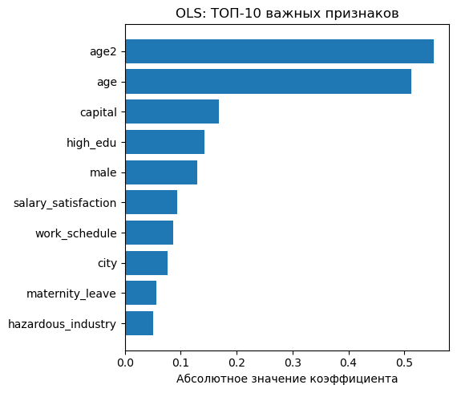

```python
# Визуализация
plt.figure(figsize=(10, 5))
plt.subplot(1, 2, 1)
top_10 = ols_coef.head(10)
plt.barh(range(10), top_10['importance_abs'])
plt.yticks(range(10), top_10['feature'])
plt.xlabel('Абсолютное значение коэффициента')
plt.title('OLS: ТОП-10 важных признаков')
plt.gca().invert_yaxis()

plt.tight_layout()
plt.show()
```

## Lasso

```python
param_grid = {'alpha': [0.001, 0.01, 0.1, 1, 10, 100]}
lasso = Lasso(max_iter=10000)
grid_search = GridSearchCV(lasso, param_grid, cv=5, scoring='neg_mean_squared_error')
grid_search.fit(X_train_scaled, y_train)

best_alpha = grid_search.best_params_['alpha']
print(f"\nОптимальный alpha (сила регуляризации): {best_alpha}")
```

```
Оптимальный alpha (сила регуляризации): 0.001
```

```python
lasso = Lasso(alpha=best_alpha, max_iter=10000)
lasso.fit(X_scaled, y)
y_pred_lasso = lasso.predict(X_scaled)


rmse_lasso = np.sqrt(mean_squared_error(y, y_pred_lasso))
mae_lasso = mean_absolute_error(y, y_pred_lasso)
r2_lasso = r2_score(y, y_pred_lasso)


all_metrics['LASSO'] = {
    'RMSE': rmse_lasso,
    'MAE': mae_lasso,
    'R2': r2_lasso
}
```

```python
lasso_coef = pd.DataFrame({
    'feature': X.columns,
    'coefficient': lasso.coef_,
    'importance_abs': np.abs(lasso.coef_)
}).sort_values('importance_abs', ascending=False)

all_coefficients['LASSO'] = lasso_coef
```

```python
# Анализ обнуленных признаков
zero_features = np.sum(lasso.coef_ == 0)
total_features = len(lasso.coef_)

print(f"RMSE: {rmse_lasso:.4f}")
print(f"MAE: {mae_lasso:.4f}")
print(f"R²: {r2_lasso:.4f}")
print(f"Обнулено признаков: {zero_features} из {total_features} ({zero_features/total_features*100:.1f}%)")
print(f"\nТоп-5 важных признаков:")
print(lasso_coef[lasso_coef['coefficient'] != 0].head(5).to_string(index=False))
```

```
RMSE: 0.4278
MAE: 0.3306
R²: 0.4061
Обнулено признаков: 0 из 26 (0.0%)

Топ-5 важных признаков:
 feature  coefficient  importance_abs
    age2        -0.46            0.46
     age         0.42            0.42
 capital         0.17            0.17
high_edu         0.13            0.13
    male         0.13            0.13
```

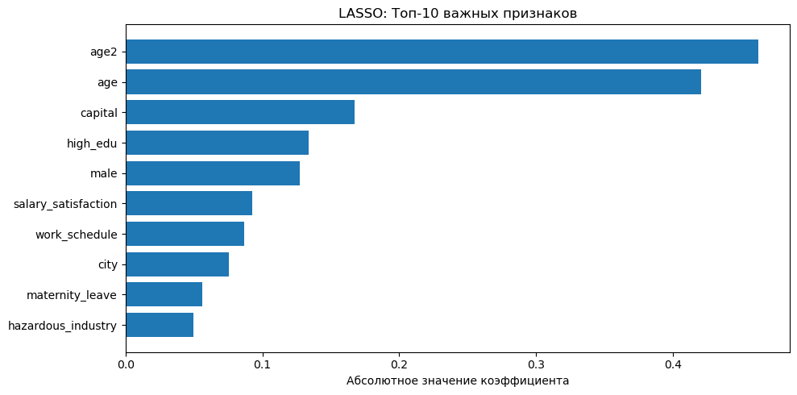

```python
plt.figure(figsize=(10, 5))

lasso_nonzero = lasso_coef[lasso_coef['coefficient'] != 0].head(10)
if len(lasso_nonzero) > 0:

    plt.barh(range(len(lasso_nonzero)), lasso_nonzero['importance_abs'])
    plt.yticks(range(len(lasso_nonzero)), lasso_nonzero['feature'])
    plt.xlabel('Абсолютное значение коэффициента')
    plt.title(f'LASSO: Топ-{len(lasso_nonzero)} важных признаков')
    plt.gca().invert_yaxis()
else:
    plt.text(0.5, 0.5, 'Все признаки обнулены', ha='center', va='center')

plt.tight_layout()
plt.show()
```

## Ridge

```python
param_grid = {'alpha': [0.001, 0.01, 0.1, 1, 10, 100, 1000]}
ridge = Ridge()
grid_search = GridSearchCV(ridge, param_grid, cv=5, scoring='neg_mean_squared_error', n_jobs=-1)
grid_search.fit(X_train_scaled, y_train)

best_alpha = grid_search.best_params_['alpha']
print(f"Оптимальный alpha для Ridge: {best_alpha}")
```

```
Оптимальный alpha для Ridge: 1
```

```python
ridge = Ridge(alpha=best_alpha)
ridge.fit(X_scaled, y)
y_pred_ridge = ridge.predict(X_scaled)

rmse_ridge = np.sqrt(mean_squared_error(y, y_pred_ridge))
mae_ridge = mean_absolute_error(y, y_pred_ridge)
r2_ridge = r2_score(y, y_pred_ridge)

all_metrics['RIDGE'] = {
    'RMSE': rmse_ridge,
    'MAE': mae_ridge,
    'R2': r2_ridge
}
```

```python
ridge_coef = pd.DataFrame({
    'feature': X.columns,
    'coefficient': ridge.coef_,
    'importance_abs': np.abs(ridge.coef_)
}).sort_values('importance_abs', ascending=False)

all_coefficients['RIDGE'] = ridge_coef

# Вывод
print(f"RMSE: {rmse_ridge:.4f}")
print(f"MAE: {mae_ridge:.4f}")
print(f"R²: {r2_ridge:.4f}")
print(f"\nТоп-5 важных признаков:")
print(ridge_coef.head(5).to_string(index=False))
```

```
RMSE: 0.4275
MAE: 0.3305
R²: 0.4068

Топ-5 важных признаков:
 feature  coefficient  importance_abs
    age2        -0.54            0.54
     age         0.50            0.50
 capital         0.17            0.17
high_edu         0.14            0.14
    male         0.13            0.13
```

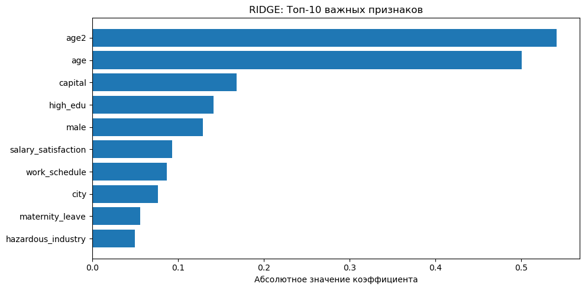

```python
plt.figure(figsize=(10, 5))


top_10_ridge = ridge_coef.head(10)
plt.barh(range(10), top_10_ridge['importance_abs'])
plt.yticks(range(10), top_10_ridge['feature'])
plt.xlabel('Абсолютное значение коэффициента')
plt.title('RIDGE: Топ-10 важных признаков')
plt.gca().invert_yaxis()

plt.tight_layout()
plt.show()
```

## Ансамблиевые модели

### Decision Tree Regression

```python
param_grid_dt = {
    'max_depth': [3, 5, 7, 10, 15, None],
    'min_samples_split': [2, 5, 10, 20],
    'min_samples_leaf': [1, 2, 4, 8],
    'max_features': ['sqrt', 'log2', None]
}

dt = DecisionTreeRegressor(random_state=42)
grid_search_dt = GridSearchCV(dt, param_grid_dt, cv=5, scoring='neg_root_mean_squared_error', n_jobs=-1)
grid_search_dt.fit(X_train, y_train)

best_dt = grid_search_dt.best_estimator_
print(f"Лучшие параметры: {grid_search_dt.best_params_}")
```

```
Лучшие параметры: {'max_depth': 7, 'max_features': None, 'min_samples_leaf': 4, 'min_samples_split': 20}
```

```python
y_pred_dt = best_dt.predict(X_test)
metrics_dt = {
    'RMSE': np.sqrt(mean_squared_error(y_test, y_pred_dt)),
    'MAE': mean_absolute_error(y_test, y_pred_dt),
    'R2': r2_score(y_test, y_pred_dt)
}

all_metrics['Decision Tree'] = metrics_dt
```

```python
dt_importance = pd.DataFrame({
    'feature': X.columns,
    'importance': best_dt.feature_importances_
}).sort_values('importance', ascending=False)
all_features_importance = {}
all_features_importance['Decision Tree'] = dt_importance
```

```python
print(f"\nМетрики на тесте:")
print(f"RMSE: {metrics_dt['RMSE']:.2f}")
print(f"MAE: {metrics_dt['MAE']:.2f}")
print(f"R²: {metrics_dt['R2']:.4f}")

print("\nТоп-10 важных признаков:")
print(dt_importance.head(10).to_string(index=False))
```

```
Метрики на тесте:
RMSE: 0.47
MAE: 0.36
R²: 0.2405

Топ-10 важных признаков:
            feature  importance
            capital        0.22
               male        0.18
      work_schedule        0.15
           high_edu        0.12
salary_satisfaction        0.10
                age        0.09
               age2        0.03
               city        0.02
    high_qualifited        0.02
     marital_status        0.01
```

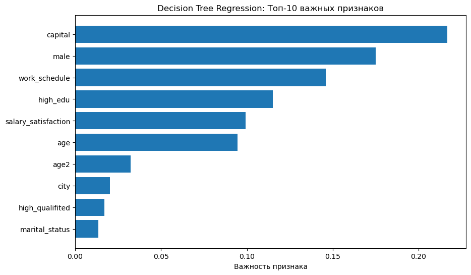

```python
plt.figure(figsize=(10, 6))
top_features_dt = dt_importance.head(10)
plt.barh(range(10), top_features_dt['importance'])
plt.yticks(range(10), top_features_dt['feature'])
plt.gca().invert_yaxis()
plt.xlabel('Важность признака')
plt.title('Decision Tree Regression: Топ-10 важных признаков')
plt.show()
```

### Random Forest Regression

```python
param_grid_rf = {
    'n_estimators': [50, 100, 200],
    'max_depth': [5, 10, 15, None],
    'min_samples_split': [2, 5, 10],
    'min_samples_leaf': [1, 2, 4],
    'max_features': ['sqrt', 'log2']
}

rf = RandomForestRegressor(random_state=42, n_jobs=-1)
grid_search_rf = GridSearchCV(rf, param_grid_rf, cv=5, scoring='neg_root_mean_squared_error', n_jobs=-1)
grid_search_rf.fit(X_train, y_train)

best_rf = grid_search_rf.best_estimator_
print(f"Лучшие параметры: {grid_search_rf.best_params_}")
```

```
Лучшие параметры: {'max_depth': None, 'max_features': 'sqrt', 'min_samples_leaf': 1, 'min_samples_split': 5, 'n_estimators': 200}
```

```python
y_pred_rf = best_rf.predict(X_test)
metrics_rf = {
    'RMSE': np.sqrt(mean_squared_error(y_test, y_pred_rf)),
    'MAE': mean_absolute_error(y_test, y_pred_rf),
    'R2': r2_score(y_test, y_pred_rf)
}

all_metrics['Random Forest'] = metrics_rf
```

```python
rf_importance = pd.DataFrame({
    'feature': X.columns,
    'importance': best_rf.feature_importances_
}).sort_values('importance', ascending=False)

all_features_importance['Random Forest'] = rf_importance
```

```python
print(f"\nМетрики на тесте:")
print(f"RMSE: {metrics_rf['RMSE']:.4f}")
print(f"MAE: {metrics_rf['MAE']:.4f}")
print(f"R²: {metrics_rf['R2']:.4f}")

print("\nТоп-10 важных признаков:")
print(rf_importance.head(10).to_string(index=False))
```

```
Метрики на тесте:
RMSE: 0.4287
MAE: 0.3246
R²: 0.3550

Топ-10 важных признаков:
                         feature  importance
                   work_schedule        0.12
                            age2        0.12
                             age        0.11
                         capital        0.10
                            male        0.08
             salary_satisfaction        0.05
                        high_edu        0.05
                            kids        0.04
                            city        0.03
financial_situation_satisfaction        0.03
```

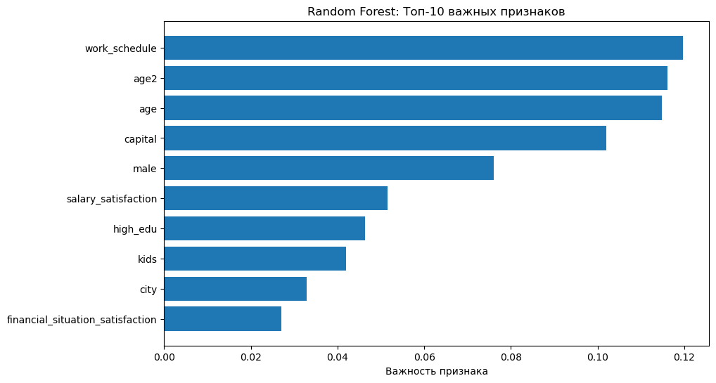

```python
plt.figure(figsize=(10, 6))
top_features = rf_importance.head(10)
plt.barh(range(10), top_features['importance'])
plt.yticks(range(10), top_features['feature'])
plt.gca().invert_yaxis()
plt.xlabel('Важность признака')
plt.title('Random Forest: Топ-10 важных признаков')
plt.show()
```

## Бустинговые модели

### Gradient Boosting

```python
param_grid_gb = {
    'n_estimators': [100, 200, 300],
    'learning_rate': [0.01, 0.05, 0.1, 0.2],
    'max_depth': [3, 4, 5, 6],
    'min_samples_split': [2, 5, 10],
    'subsample': [0.8, 0.9, 1.0]
}

gb = GradientBoostingRegressor(random_state=42)
grid_search_gb = GridSearchCV(gb, param_grid_gb, cv=5, scoring='neg_root_mean_squared_error', n_jobs=-1, verbose=0)
grid_search_gb.fit(X_train, y_train)

best_gb = grid_search_gb.best_estimator_
print(f"Лучшие параметры: {grid_search_gb.best_params_}")
```

```
Лучшие параметры: {'learning_rate': 0.05, 'max_depth': 4, 'min_samples_split': 10, 'n_estimators': 200, 'subsample': 0.8}
```

```python
y_pred_gb = best_gb.predict(X_test)
metrics_gb = {
    'RMSE': np.sqrt(mean_squared_error(y_test, y_pred_gb)),
    'MAE': mean_absolute_error(y_test, y_pred_gb),
    'R2': r2_score(y_test, y_pred_gb)
}

all_metrics['Gradient Boosting'] = metrics_gb
```

```python
gb_importance = pd.DataFrame({
    'feature': X.columns,
    'importance': best_gb.feature_importances_
}).sort_values('importance', ascending=False)

all_features_importance['Gradient Boosting'] = gb_importance
```

```python
print(f"\nМетрики на тесте:")
print(f"RMSE: {metrics_gb['RMSE']:.2f}")
print(f"MAE: {metrics_gb['MAE']:.2f}")
print(f"R²: {metrics_gb['R2']:.4f}")

print("\nТоп-10 важных признаков:")
print(gb_importance.head(10).to_string(index=False))
```

```
Метрики на тесте:
RMSE: 0.43
MAE: 0.33
R²: 0.3564

Топ-10 важных признаков:
                         feature  importance
                   work_schedule        0.16
                         capital        0.15
                            male        0.11
                        high_edu        0.08
                            age2        0.07
             salary_satisfaction        0.07
                             age        0.07
                            city        0.04
financial_situation_satisfaction        0.02
                 high_qualifited        0.02
```

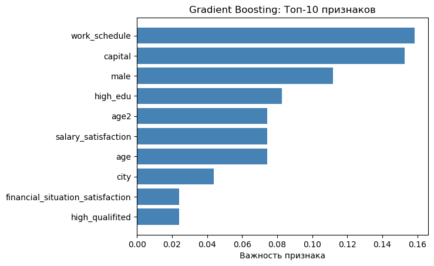

```python
gb_top10 = all_features_importance['Gradient Boosting'].head(10)
plt.barh(range(10), gb_top10['importance'], color='steelblue')
plt.yticks(range(10), gb_top10['feature'])
plt.xlabel('Важность признака')
plt.title('Gradient Boosting: Топ-10 признаков')
plt.gca().invert_yaxis()
```

### XGBoost

```python
param_grid_xgb = {
    'n_estimators': [100, 200, 300],
    'max_depth': [3, 4, 5, 6],
    'learning_rate': [0.01, 0.05, 0.1],
    'subsample': [0.8, 0.9, 1.0],
    'colsample_bytree': [0.8, 0.9, 1.0]
}

xgb_model = xgb.XGBRegressor(random_state=42, n_jobs=-1, verbosity=0)
grid_search_xgb = GridSearchCV(xgb_model, param_grid_xgb, cv=5, scoring='neg_root_mean_squared_error', n_jobs=-1, verbose=0)
grid_search_xgb.fit(X_train, y_train)

best_xgb = grid_search_xgb.best_estimator_
print(f"Лучшие параметры: {grid_search_xgb.best_params_}")
```

```
Лучшие параметры: {'colsample_bytree': 0.8, 'learning_rate': 0.05, 'max_depth': 4, 'n_estimators': 200, 'subsample': 0.8}
```

```python
y_pred_xgb = best_xgb.predict(X_test)
metrics_xgb = {
    'RMSE': np.sqrt(mean_squared_error(y_test, y_pred_xgb)),
    'MAE': mean_absolute_error(y_test, y_pred_xgb),
    'R2': r2_score(y_test, y_pred_xgb)
}

all_metrics['XGBoost'] = metrics_xgb
```

```python
xgb_importance = pd.DataFrame({
    'feature': X.columns,
    'importance': best_xgb.feature_importances_
}).sort_values('importance', ascending=False)

all_features_importance['XGBoost'] = xgb_importance
```

```python
print(f"\nМетрики на тесте:")
print(f"RMSE: {metrics_xgb['RMSE']:.2f}")
print(f"MAE: {metrics_xgb['MAE']:.2f}")
print(f"R²: {metrics_xgb['R2']:.4f}")

print("\nТоп-10 важных признаков:")
print(xgb_importance.head(10).to_string(index=False))
```

```
Метрики на тесте:
RMSE: 0.43
MAE: 0.33
R²: 0.3613

Топ-10 важных признаков:
                         feature  importance
                         capital        0.15
                            male        0.10
             salary_satisfaction        0.10
                        high_edu        0.10
                            city        0.06
                      self_owner        0.05
                 high_qualifited        0.04
financial_situation_satisfaction        0.04
                 maternity_leave        0.04
                   work_schedule        0.04
```

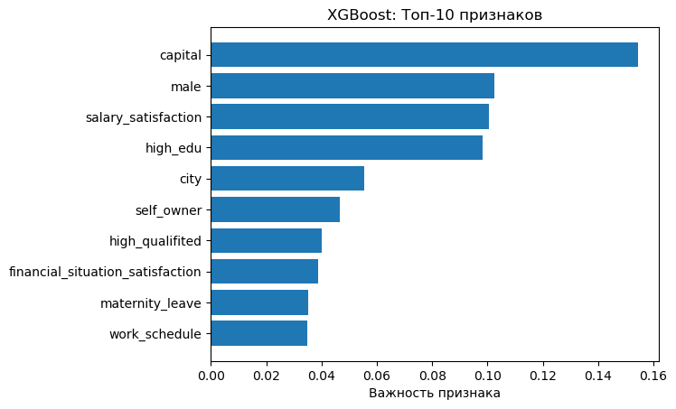

```python
xgb_top10 = all_features_importance['XGBoost'].head(10)
plt.barh(range(10), xgb_top10['importance'])
plt.yticks(range(10), xgb_top10['feature'])
plt.xlabel('Важность признака')
plt.title('XGBoost: Топ-10 признаков')
plt.gca().invert_yaxis()
```

## Результаты

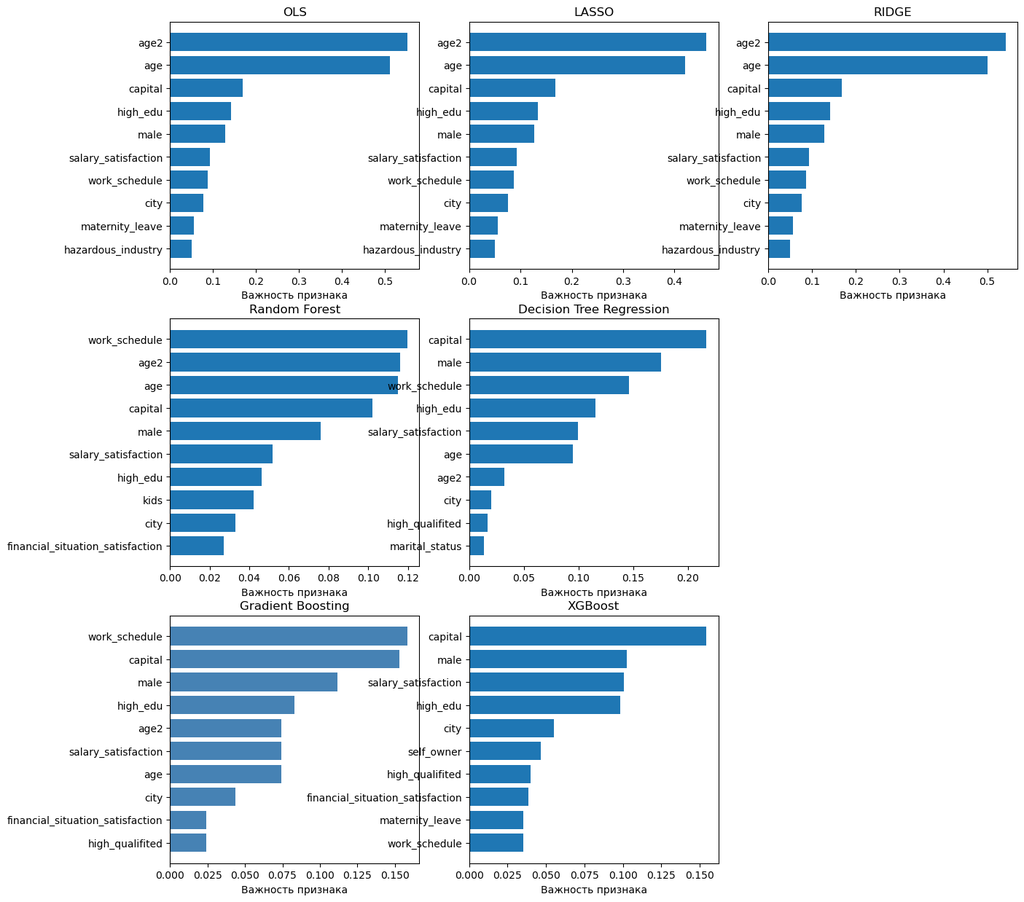

```python
plt.figure(figsize=(15, 15))
plt.subplot(3, 3, 1)
top_10 = ols_coef.head(10)
plt.barh(range(10), top_10['importance_abs'])
plt.yticks(range(10), top_10['feature'])
plt.xlabel('Важность признака')
plt.title('OLS')
plt.gca().invert_yaxis()

plt.subplot(3, 3, 2)
plt.barh(range(len(lasso_nonzero)), lasso_nonzero['importance_abs'])
plt.yticks(range(len(lasso_nonzero)), lasso_nonzero['feature'])
plt.xlabel('Важность признака')
plt.title(f'LASSO')
plt.gca().invert_yaxis()

plt.subplot(3, 3, 3)
plt.barh(range(10), top_10_ridge['importance_abs'])
plt.yticks(range(10), top_10_ridge['feature'])
plt.xlabel('Важность признака')
plt.title('RIDGE')
plt.gca().invert_yaxis()

plt.subplot(3, 3, 4)
plt.barh(range(10), top_features['importance'])
plt.yticks(range(10), top_features['feature'])
plt.gca().invert_yaxis()
plt.xlabel('Важность признака')
plt.title('Random Forest')

plt.subplot(3, 3, 5)
plt.barh(range(10), top_features_dt['importance'])
plt.yticks(range(10), top_features_dt['feature'])
plt.gca().invert_yaxis()
plt.xlabel('Важность признака')
plt.title('Decision Tree Regression')

plt.subplot(3, 3, 7)
plt.barh(range(10), gb_top10['importance'], color='steelblue')
plt.yticks(range(10), gb_top10['feature'])
plt.xlabel('Важность признака')
plt.title('Gradient Boosting')
plt.gca().invert_yaxis()

plt.subplot(3, 3, 8)
plt.barh(range(10), xgb_top10['importance'])
plt.yticks(range(10), xgb_top10['feature'])
plt.xlabel('Важность признака')
plt.title('XGBoost')
plt.gca().invert_yaxis()
```

```python
all_models = ['OLS', 'LASSO', 'RIDGE', 'Decision Tree', 'Random Forest', 'Gradient Boosting', 'XGBoost']
full_metrics_df = pd.DataFrame({model: all_metrics.get(model, {}) for model in all_models}).T
full_metrics_df = full_metrics_df[['RMSE', 'MAE']]
full_metrics_df_sorted = full_metrics_df.sort_values('RMSE', ascending=True)


pd.set_option('display.float_format', '{:.5f}'.format)
full_metrics_df_sorted
```

|  | RMSE | MAE |
| --- | --- | --- |
| XGBoost | 0.42659 | 0.32614 |
| OLS | 0.42753 | 0.33052 |
| RIDGE | 0.42754 | 0.33050 |
| LASSO | 0.42779 | 0.33056 |
| Gradient Boosting | 0.42820 | 0.32776 |
| Random Forest | 0.42868 | 0.32464 |
| Decision Tree | 0.46518 | 0.35557 |

Для ваших данных сложность модели практически не дает выигрыша в точности. Простые линейные модели работают так же хорошо, как современные ансамблевые алгоритмы. Тот факт, что OLS ≈ RIDGE ≈ LASSO, говорит о:

- Отсутствии серьезной мультиколлинеарности между признаками
- Преобладании линейных зависимостей зарплаты от факторов
- Эффективности простых моделей для вашего набора данных

# Кластеризация

```python
X_cluster = rdf.drop('log_salary', axis=1).copy()

scaler_cluster = StandardScaler()
X_scaled = scaler_cluster.fit_transform(X_cluster)

print(f"Данные для кластеризации: {X_scaled.shape}")
print(f"Признаки: {list(X_cluster.columns)}")
```

```
Данные для кластеризации: (4278, 26)
Признаки: ['male', 'age', 'age2', 'capital', 'city', 'urban_type', 'marital_status', 'secondary_edu', 'proff_edu', 'high_edu', 'high_qualifited', 'maternity_leave', 'kids', 'labour_conditions_satisfaction', 'salary_satisfaction', 'promotion_satisfaction', 'work_schedule', 'hazardous_industry', 'stat…
```

```python
inertia = []
silhouette_scores = []
k_range = range(2, 11)

for k in k_range:
    kmeans = KMeans(n_clusters=k, random_state=42, n_init=10)
    kmeans.fit(X_scaled)
    inertia.append(kmeans.inertia_)


    if k > 1:
        silhouette_scores.append(silhouette_score(X_scaled, kmeans.labels_))
    else:
        silhouette_scores.append(0)
```

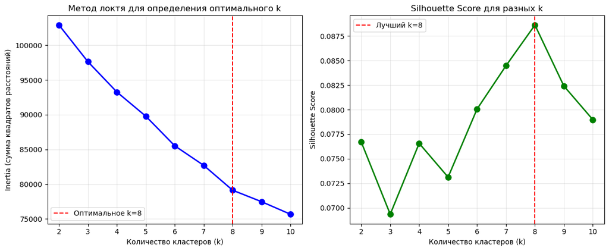

```python
fig, axes = plt.subplots(1, 2, figsize=(12, 5))

axes[0].plot(k_range, inertia, 'bo-', linewidth=2, markersize=8)
axes[0].set_xlabel('Количество кластеров (k)')
axes[0].set_ylabel('Inertia (сумма квадратов расстояний)')
axes[0].set_title('Метод локтя для определения оптимального k')
axes[0].grid(True, alpha=0.3)

inertia_diff = np.diff(inertia)
inertia_diff_ratio = inertia_diff[1:] / inertia_diff[:-1]


elbow_point = np.where(inertia_diff_ratio < 0.5)[0]
optimal_k_elbow = elbow_point[0] + 3 if len(elbow_point) > 0 else 4

axes[0].axvline(x=optimal_k_elbow, color='red', linestyle='--',
                label=f'Оптимальное k={optimal_k_elbow}')
axes[0].legend()

axes[1].plot(k_range, silhouette_scores, 'go-', linewidth=2, markersize=8)
axes[1].set_xlabel('Количество кластеров (k)')
axes[1].set_ylabel('Silhouette Score')
axes[1].set_title('Silhouette Score для разных k')
axes[1].grid(True, alpha=0.3)

optimal_k_silhouette = k_range[np.argmax(silhouette_scores)]
axes[1].axvline(x=optimal_k_silhouette, color='red', linestyle='--',
                label=f'Лучший k={optimal_k_silhouette}')
axes[1].legend()

plt.tight_layout()
plt.show()
```

```python
optimal_k = optimal_k_silhouette
print(f"Рекомендованное количество кластеров: {optimal_k}")
print(f"  - По методу локтя: {optimal_k_elbow}")
print(f"  - По silhouette score: {optimal_k_silhouette}")
```

```
Рекомендованное количество кластеров: 8
  - По методу локтя: 8
  - По silhouette score: 8
```

```python
kmeans_final = KMeans(n_clusters=optimal_k, random_state=42, n_init=20)
cluster_labels = kmeans_final.fit_predict(X_scaled)

df_clustered = df.copy()
df_clustered['cluster'] = cluster_labels
df_clustered['cluster'] = df_clustered['cluster'].astype('category')

print(f"\nКластеризация завершена. Распределение по кластерам:")
cluster_counts = df_clustered['cluster'].value_counts().sort_index()
for cluster, count in cluster_counts.items():
    print(f"  Кластер {cluster+1}: {count} записей ({count/len(df_clustered)*100:.1f}%)")
```

```
Кластеризация завершена. Распределение по кластерам:
  Кластер 1: 49 записей (1.1%)
  Кластер 2: 759 записей (17.7%)
  Кластер 3: 693 записей (16.2%)
  Кластер 4: 749 записей (17.5%)
  Кластер 5: 308 записей (7.2%)
  Кластер 6: 680 записей (15.9%)
  Кластер 7: 924 записей (21.6%)
  Кластер 8: 116 записей (2.7%)
```

```python
cluster_summary = df_clustered.groupby('cluster').mean().round(2)
cluster_summary['salary'] = np.exp(cluster_summary['log_salary'])
cluster_summary['count'] = cluster_counts
cluster_summary['percentage'] = (cluster_summary['count'] / len(df_clustered) * 100).round(1)

print("\nСредние значения по кластерам:")
cluster_summary
```

```
Средние значения по кластерам:
```

| cluster | male | age | age2 | capital | city | urban_type | marital_status | secondary_edu | proff_edu | high_edu | high_qualifited | maternity_leave | kids | labour_conditions_satisfaction | salary_satisfaction | promotion_satisfaction | work_schedule | hazardous_industry | state_owner | self_owner | management_trust | new_job_confidence | life_satisfaction | financial_situation_satisfaction | foreign_language | health | experience | experience^2 | log_salary | … |
| --- | --- | --- | --- | --- | --- | --- | --- | --- | --- | --- | --- | --- | --- | --- | --- | --- | --- | --- | --- | --- | --- | --- | --- | --- | --- | --- | --- | --- | --- | --- |
| 0 | 0.00000 | 32.06000 | 1064.15000 | 0.18000 | 0.80000 | 0.06000 | 0.82000 | 0.14000 | 0.22000 | 0.59000 | 0.04000 | 1.00000 | 1.57000 | 0.82000 | 0.43000 | 0.71000 | 41.57000 | 0.08000 | 0.49000 | 0.00000 | 0.76000 | 0.49000 | 0.90000 | 0.31000 | 0.41000 | 0.65000 | 9.60000 | 128.88000 | 9.92000 | … |
| 1 | 0.55000 | 29.35000 | 903.58000 | 0.25000 | 0.86000 | 0.00000 | 0.19000 | 0.12000 | 0.39000 | 0.38000 | 0.01000 | 0.00000 | 0.23000 | 0.91000 | 0.52000 | 0.69000 | 43.03000 | 0.13000 | 0.32000 | 0.00000 | 0.82000 | 0.67000 | 0.74000 | 0.32000 | 0.42000 | 0.79000 | 7.31000 | 89.67000 | 10.54000 | … |
| 2 | 0.54000 | 44.88000 | 2124.20000 | 0.17000 | 0.80000 | 0.00000 | 0.57000 | 0.39000 | 0.24000 | 0.23000 | 0.02000 | 0.00000 | 1.31000 | 0.08000 | 0.06000 | 0.09000 | 44.87000 | 0.10000 | 0.30000 | 0.00000 | 0.45000 | 0.38000 | 0.28000 | 0.06000 | 0.11000 | 0.31000 | 20.48000 | 536.57000 | 10.40000 | … |
| 3 | 0.59000 | 49.15000 | 2519.41000 | 0.13000 | 0.72000 | 0.00000 | 0.63000 | 0.92000 | 0.00000 | 0.00000 | 0.02000 | 0.00000 | 1.60000 | 0.94000 | 0.48000 | 0.72000 | 44.59000 | 0.11000 | 0.37000 | 0.00000 | 0.86000 | 0.36000 | 0.67000 | 0.32000 | 0.04000 | 0.44000 | 24.97000 | 754.27000 | 10.38000 | … |
| 4 | 0.43000 | 44.89000 | 2164.52000 | 0.23000 | 0.00000 | 1.00000 | 0.53000 | 0.35000 | 0.26000 | 0.34000 | 0.04000 | 0.00000 | 1.43000 | 0.81000 | 0.55000 | 0.67000 | 41.76000 | 0.16000 | 0.46000 | 0.00000 | 0.84000 | 0.53000 | 0.56000 | 0.23000 | 0.23000 | 0.58000 | 20.11000 | 553.19000 | 10.42000 | … |
| 5 | 0.33000 | 51.14000 | 2704.69000 | 0.14000 | 0.70000 | 0.00000 | 0.67000 | 0.00000 | 0.94000 | 0.00000 | 0.02000 | 0.00000 | 1.63000 | 0.89000 | 0.41000 | 0.73000 | 40.85000 | 0.14000 | 0.53000 | 0.00000 | 0.84000 | 0.31000 | 0.68000 | 0.23000 | 0.06000 | 0.41000 | 27.28000 | 858.26000 | 10.29000 | … |
| 6 | 0.32000 | 47.23000 | 2332.11000 | 0.21000 | 0.85000 | 0.00000 | 0.71000 | 0.00000 | 0.00000 | 0.99000 | 0.14000 | 0.00000 | 1.55000 | 0.95000 | 0.53000 | 0.75000 | 40.36000 | 0.17000 | 0.60000 | 0.00000 | 0.87000 | 0.38000 | 0.73000 | 0.34000 | 0.38000 | 0.47000 | 23.73000 | 672.34000 | 10.68000 | … |
| 7 | 0.63000 | 44.97000 | 2130.41000 | 0.12000 | 0.80000 | 0.08000 | 0.67000 | 0.20000 | 0.26000 | 0.46000 | 0.34000 | 0.00000 | 1.42000 | 0.90000 | 0.65000 | 0.75000 | 42.78000 | 0.01000 | 0.03000 | 1.00000 | 0.78000 | 0.50000 | 0.66000 | 0.40000 | 0.36000 | 0.57000 | 20.62000 | 558.11000 | 10.92000 | … |

```python
cluster_summary = df_clustered.groupby('cluster').median().round(2)
cluster_summary['salary'] = np.exp(cluster_summary['log_salary'])
cluster_summary['count'] = cluster_counts
cluster_summary['percentage'] = (cluster_summary['count'] / len(df_clustered) * 100).round(1)

print("Медианные значения по кластерам:")
cluster_summary
```

```
Медианные значения по кластерам:
```

| cluster | male | age | age2 | capital | city | urban_type | marital_status | secondary_edu | proff_edu | high_edu | high_qualifited | maternity_leave | kids | labour_conditions_satisfaction | salary_satisfaction | promotion_satisfaction | work_schedule | hazardous_industry | state_owner | self_owner | management_trust | new_job_confidence | life_satisfaction | financial_situation_satisfaction | foreign_language | health | experience | experience^2 | log_salary | … |
| --- | --- | --- | --- | --- | --- | --- | --- | --- | --- | --- | --- | --- | --- | --- | --- | --- | --- | --- | --- | --- | --- | --- | --- | --- | --- | --- | --- | --- | --- | --- |
| 0 | 0.00000 | 32.50000 | 1056.25000 | 0.00000 | 1.00000 | 0.00000 | 1.00000 | 0.00000 | 0.00000 | 1.00000 | 0.00000 | 1.00000 | 1.00000 | 1.00000 | 0.00000 | 1.00000 | 40.00000 | 0.00000 | 0.00000 | 0.00000 | 1.00000 | 0.00000 | 1.00000 | 0.00000 | 0.00000 | 1.00000 | 9.00000 | 81.00000 | 9.90000 | … |
| 1 | 1.00000 | 28.50000 | 812.25000 | 0.00000 | 1.00000 | 0.00000 | 0.00000 | 0.00000 | 0.00000 | 0.00000 | 0.00000 | 0.00000 | 0.00000 | 1.00000 | 1.00000 | 1.00000 | 40.00000 | 0.00000 | 0.00000 | 0.00000 | 1.00000 | 1.00000 | 1.00000 | 0.00000 | 0.00000 | 1.00000 | 6.00000 | 36.00000 | 10.60000 | … |
| 2 | 1.00000 | 44.50000 | 1980.25000 | 0.00000 | 1.00000 | 0.00000 | 1.00000 | 0.00000 | 0.00000 | 0.00000 | 0.00000 | 0.00000 | 1.00000 | 0.00000 | 0.00000 | 0.00000 | 40.00000 | 0.00000 | 0.00000 | 0.00000 | 0.00000 | 0.00000 | 0.00000 | 0.00000 | 0.00000 | 0.00000 | 20.00000 | 400.00000 | 10.40000 | … |
| 3 | 1.00000 | 49.00000 | 2401.00000 | 0.00000 | 1.00000 | 0.00000 | 1.00000 | 1.00000 | 0.00000 | 0.00000 | 0.00000 | 0.00000 | 2.00000 | 1.00000 | 0.00000 | 1.00000 | 40.00000 | 0.00000 | 0.00000 | 0.00000 | 1.00000 | 0.00000 | 1.00000 | 0.00000 | 0.00000 | 0.00000 | 25.00000 | 625.00000 | 10.37000 | … |
| 4 | 0.00000 | 44.50000 | 1980.25000 | 0.00000 | 0.00000 | 1.00000 | 1.00000 | 0.00000 | 0.00000 | 0.00000 | 0.00000 | 0.00000 | 1.00000 | 1.00000 | 1.00000 | 1.00000 | 40.00000 | 0.00000 | 0.00000 | 0.00000 | 1.00000 | 1.00000 | 1.00000 | 0.00000 | 0.00000 | 1.00000 | 19.00000 | 361.00000 | 10.43000 | … |
| 5 | 0.00000 | 51.50000 | 2652.25000 | 0.00000 | 1.00000 | 0.00000 | 1.00000 | 0.00000 | 1.00000 | 0.00000 | 0.00000 | 0.00000 | 2.00000 | 1.00000 | 0.00000 | 1.00000 | 40.00000 | 0.00000 | 1.00000 | 0.00000 | 1.00000 | 0.00000 | 1.00000 | 0.00000 | 0.00000 | 0.00000 | 28.00000 | 784.00000 | 10.31000 | … |
| 6 | 0.00000 | 46.50000 | 2162.25000 | 0.00000 | 1.00000 | 0.00000 | 1.00000 | 0.00000 | 0.00000 | 1.00000 | 0.00000 | 0.00000 | 2.00000 | 1.00000 | 1.00000 | 1.00000 | 40.00000 | 0.00000 | 1.00000 | 0.00000 | 1.00000 | 0.00000 | 1.00000 | 0.00000 | 0.00000 | 0.00000 | 22.36000 | 499.75000 | 10.63000 | … |
| 7 | 1.00000 | 45.50000 | 2070.25000 | 0.00000 | 1.00000 | 0.00000 | 1.00000 | 0.00000 | 0.00000 | 0.00000 | 0.00000 | 0.00000 | 1.00000 | 1.00000 | 1.00000 | 1.00000 | 40.00000 | 0.00000 | 0.00000 | 1.00000 | 1.00000 | 0.50000 | 1.00000 | 0.00000 | 0.00000 | 1.00000 | 20.50000 | 420.50000 | 10.82000 | … |

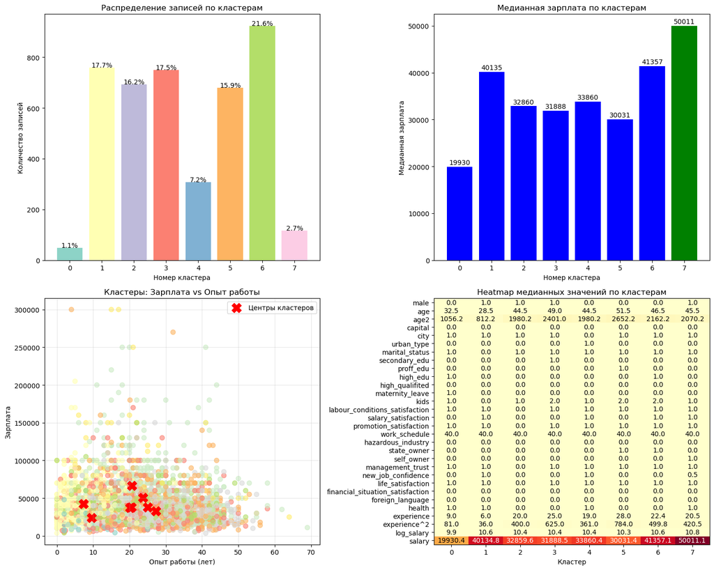

```python
cluster_summary['salary'] = np.exp(cluster_summary['log_salary'])
df_clustered['salary'] = np.exp(df_clustered['log_salary'])

fig, axes = plt.subplots(2, 2, figsize=(15, 12))


axes[0, 0].bar(cluster_summary.index, cluster_summary['count'],
               color=plt.cm.Set3(range(optimal_k)))
axes[0, 0].set_xlabel('Номер кластера')
axes[0, 0].set_ylabel('Количество записей')
axes[0, 0].set_title('Распределение записей по кластерам')
for i, (idx, row) in enumerate(cluster_summary.iterrows()):
    axes[0, 0].text(idx, row['count'] + 2, f"{row['percentage']}%",
                   ha='center', fontsize=10)


salary_by_cluster = cluster_summary['salary'].sort_values(ascending=False)
colors_salary = ['green' if i == salary_by_cluster.index[0] else 'blue'
                for i in salary_by_cluster.index]

bars = axes[0, 1].bar(salary_by_cluster.index, salary_by_cluster.values,
                      color=colors_salary)
axes[0, 1].set_xlabel('Номер кластера')
axes[0, 1].set_ylabel('Медианная зарплата')
axes[0, 1].set_title('Медианная зарплата по кластерам')


for bar, salary in zip(bars, salary_by_cluster.values):
    axes[0, 1].text(bar.get_x() + bar.get_width()/2, bar.get_height() + 500,
                   f'{salary:.0f}', ha='center', fontsize=10)


scatter1 = axes[1, 0].scatter(df_clustered['experience'],
                              df_clustered['salary'],
                              c=df_clustered['cluster'],
                              cmap='Set3',
                              alpha=0.6,
                              s=50)
axes[1, 0].set_xlabel('Опыт работы (лет)')
axes[1, 0].set_ylabel('Зарплата')
axes[1, 0].set_title('Кластеры: Зарплата vs Опыт работы')
axes[1, 0].grid(True, alpha=0.3)


centers = df_clustered.groupby('cluster')[['experience', 'salary']].mean()
axes[1, 0].scatter(centers['experience'], centers['salary'],
                   c='red', s=200, marker='X', label='Центры кластеров')
axes[1, 0].legend()



heatmap_data = cluster_summary.drop(['count', 'percentage'], axis=1).T

im = axes[1, 1].imshow(heatmap_data, aspect='auto', cmap='YlOrRd')
axes[1, 1].set_xticks(range(len(heatmap_data.columns)))
axes[1, 1].set_yticks(range(len(heatmap_data.index)))
axes[1, 1].set_xticklabels(heatmap_data.columns)
axes[1, 1].set_yticklabels(heatmap_data.index)
axes[1, 1].set_xlabel('Кластер')
axes[1, 1].set_title('Heatmap медианных значений по кластерам')

# Добавляем значения в ячейки
for i in range(len(heatmap_data.index)):
    for j in range(len(heatmap_data.columns)):
        text = axes[1, 1].text(j, i, f'{heatmap_data.iloc[i, j]:.1f}',
                              ha="center", va="center",
                              color="black" if heatmap_data.iloc[i, j] <
                              heatmap_data.values.max()/2 else "white")

plt.tight_layout()
plt.show()
```

```python
# Применяем PCA для сокращения до 2 измерений
pca = PCA(n_components=2)
X_pca = pca.fit_transform(X_scaled)


pca_df = pd.DataFrame(X_pca, columns=['PC1', 'PC2'])
pca_df['cluster'] = cluster_labels
pca_df['salary'] = np.exp(df['log_salary']).values
```

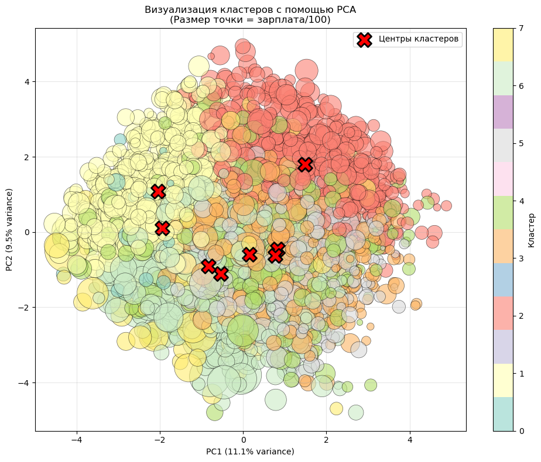

```python
plt.figure(figsize=(10, 8))


scatter = plt.scatter(pca_df['PC1'], pca_df['PC2'],
                     c=pca_df['cluster'],
                     cmap='Set3',
                     s=pca_df['salary']/100,
                     alpha=0.6,
                     edgecolors='black',
                     linewidth=0.5)

plt.xlabel(f'PC1 ({pca.explained_variance_ratio_[0]*100:.1f}% variance)')
plt.ylabel(f'PC2 ({pca.explained_variance_ratio_[1]*100:.1f}% variance)')
plt.title('Визуализация кластеров с помощью PCA\n(Размер точки = зарплата/100)')
plt.colorbar(scatter, label='Кластер')
plt.grid(True, alpha=0.3)


centers_pca = pd.DataFrame({
    'PC1': pca_df.groupby('cluster')['PC1'].mean(),
    'PC2': pca_df.groupby('cluster')['PC2'].mean()
})

plt.scatter(centers_pca['PC1'], centers_pca['PC2'],
           c='red', s=300, marker='X', label='Центры кластеров',
           edgecolors='black', linewidth=2)

plt.legend()
plt.tight_layout()
plt.show()
```